# Homework Week 6

name

May 12, 2024

# Question 1

Code up the model from Week 4 in stan where our model ($\mathcal{M}1$) was:

$$\begin{align}
y \sim & N(\mu, \sigma) \quad [\text{Likelihood}] \\
& \mu ~ \sim N(\mu_0 = 100, \sigma_0 = 10) \quad [\text{Prior}]\\
& \sigma = 15 \quad [\text{Constant}]
\end{align}$$

There’s two ways to do this in a rmarkdown:

1. You can write the model into an rmarkdown chunk that calls `stan` and provides the `output.var=` as the model name: “model1”. This calls `stan_model()` for you in the background.
2. Write a ‘model1.stan’ file and load and compile it with ‘stan_model(file = “model1.stan” )’

The model should also contain a `generated_quantities{}` block that generates values for the predictive distribution ‘y_rep’ and computes the log likelihood for each value as ‘log_lik’.

In your code, remove the ‘eval = FALSE’ or set it to ‘TRUE’, otherwise the chunk will not be evaluated.

```stan
// Paste the model1.stan code here:
data {
  int<lower=1> N;
  vector[N] y;
  real<lower=0> sigma;
}

parameters {
  real mu;

}

model {
  // Prior
  mu ~ normal(100, 10);
  // likelihood
  y ~ normal(mu, sigma);
}

generated quantities {
  real y_rep[N];
  real log_lik[N];
  for( i in 1:N ){
    y_rep[i] = normal_rng( mu, sigma );
  }
  for(n in 1:N) {
    log_lik[n] = normal_lpdf(y[n] | mu, sigma);
  }
}
```

If you save the code in an external file ‘model1.stan’, do this instead:

```r
## Load and compile the model
model1 <- stan_model(file = "./model1.stan" )
```

# Question 2

Now sample from the model given this data:

```r
set.seed(433)
y <- rbinom(30, 200, .65)
set.seed(NULL )
```

Save the data as a list, so that stan can sample your model:

```r
## Create a data list:
stan_data <- list(y = y,
                  N = length(y),
                  sigma = 15)
## Sample:
fitted <- sampling(model1, data = stan_data )
```

Print the model results, parse the table so that only “mu” is printed:

```r
## Results:
summary(fitted, pars = "mu")$summary
```

```
##        mean    se_mean       sd     2.5%      25%      50%      75%    97.5%
## mu 127.2461 0.07031514 2.699067 121.9237 125.4677 127.2367 129.0983 132.3891
##       n_eff     Rhat
## mu 1473.431 1.000909
```

# Question 3

Now, adapt your stan code to represent this model:

$$\begin{align}
y \sim & N(\mu, \sigma) \quad [\text{Likelihood}] \\
& \mu ~ \sim N(\mu_0 = 100, \sigma_0 = 10) \quad [\text{Prior on
}\mu]\\
& \sigma ~ \sim \Gamma(10, 1 ) \quad [\text{Prior on }\sigma]
\end{align}$$

and save the file into “model2.stan”

```stan
// Stan model 2 code:
data {
  int<lower=1> N;
  vector[N] y;
}

parameters {
  real mu;
  real<lower=0> sigma;
}

model {
  // Prior
  mu ~ normal(100, 10);
  // likelihood
  y ~ normal(mu, sigma);
}

generated quantities {
  real y_rep[N];
  real log_lik[N];
  for( i in 1:N ){
    y_rep[i] = normal_rng( mu, sigma );
  }
  for(n in 1:N) {
    log_lik[n] = normal_lpdf(y[n] | mu, sigma);
  }
}
```

Sample and print output:

```r
## Code:

stan_data2 <- list(y = y,
                  N = length(y))

fitted2 <- sampling(model2, data = stan_data2 )

kableExtra::kbl(summary(fitted2)$summary)
```

|  | mean | se_mean | sd | 2.5% | 25% | 50% | 75% | 97.5% | n_eff | Rhat |
| --- | --- | --- | --- | --- | --- | --- | --- | --- | --- | --- |
| mu | 128.798168 | 0.0250481 | 1.2193996 | 126.319296 | 128.020136 | 128.809771 | 129.604756 | 131.133462 | 2369.962 | 0.9994610 |
| sigma | 6.486292 | 0.0174710 | 0.8923432 | 4.993818 | 5.838990 | 6.390500 | 7.025978 | 8.528762 | 2608.729 | 1.0004237 |
| y_rep[1] | 128.695902 | 0.1107106 | 6.7940425 | 115.303880 | 124.263215 | 128.800824 | 133.141044 | 141.743056 | 3765.984 | 0.9995336 |
| y_rep[2] | 128.838775 | 0.1064054 | 6.6577959 | 115.451336 | 124.570189 | 128.858509 | 133.238356 | 141.712909 | 3915.019 | 0.9997577 |
| y_rep[3] | 128.732515 | 0.1060732 | 6.6231510 | 115.596070 | 124.403118 | 128.741926 | 133.197580 | 141.163779 | 3898.682 | 1.0003974 |
| y_rep[4] | 128.858668 | 0.1128964 | 6.6698841 | 115.734942 | 124.369657 | 128.795324 | 133.390309 | 141.678710 | 3490.410 | 1.0003875 |
| y_rep[5] | 128.790098 | 0.1096503 | 6.6989671 | 115.403573 | 124.350011 | 128.902434 | 133.164063 | 141.710281 | 3732.471 | 0.9996088 |
| y_rep[6] | 128.849721 | 0.1089558 | 6.8086109 | 115.405553 | 124.295727 | 128.903881 | 133.341356 | 142.268337 | 3904.954 | 0.9999870 |
| y_rep[7] | 128.878890 | 0.1028707 | 6.4973091 | 115.945293 | 124.612918 | 128.854573 | 133.109086 | 141.738345 | 3989.183 | 0.9996630 |
| y_rep[8] | 128.828421 | 0.1115895 | 6.7041360 | 115.580369 | 124.436420 | 128.737339 | 133.147968 | 142.581567 | 3609.433 | 1.0006121 |
| y_rep[9] | 128.811295 | 0.1071945 | 6.7107301 | 115.683531 | 124.256350 | 128.965670 | 133.277705 | 141.634315 | 3919.170 | 0.9995224 |
| y_rep[10] | 128.747930 | 0.1102475 | 6.7333825 | 115.589471 | 124.253595 | 128.759565 | 133.259129 | 141.791687 | 3730.174 | 0.9996072 |
| y_rep[11] | 128.606371 | 0.1088159 | 6.7509919 | 114.822944 | 124.131776 | 128.783384 | 133.130941 | 141.608195 | 3849.023 | 0.9999781 |
| y_rep[12] | 128.748283 | 0.1046415 | 6.5482470 | 116.041698 | 124.359189 | 128.790917 | 132.945855 | 141.755768 | 3915.996 | 0.9999872 |
| y_rep[13] | 128.844896 | 0.1072366 | 6.5599127 | 116.187895 | 124.414877 | 128.812329 | 133.147251 | 141.588251 | 3742.054 | 1.0009787 |
| y_rep[14] | 128.756396 | 0.1045075 | 6.5743783 | 116.197759 | 124.347985 | 128.668296 | 132.909248 | 141.760603 | 3957.441 | 1.0003842 |
| y_rep[15] | 128.854480 | 0.1093726 | 6.8114803 | 115.203950 | 124.498869 | 128.714968 | 133.200509 | 142.410689 | 3878.519 | 0.9995070 |
| y_rep[16] | 128.806906 | 0.1062982 | 6.6731982 | 115.890255 | 124.454972 | 128.704720 | 133.083304 | 142.227814 | 3941.092 | 0.9999263 |
| y_rep[17] | 128.730742 | 0.1084404 | 6.6774044 | 115.391924 | 124.424191 | 128.769427 | 133.227714 | 141.797163 | 3791.694 | 0.9995117 |
| y_rep[18] | 128.893053 | 0.1059868 | 6.5994565 | 116.221620 | 124.407018 | 128.748984 | 133.209991 | 142.179134 | 3877.149 | 0.9997844 |
| y_rep[19] | 128.899015 | 0.1067885 | 6.7756249 | 115.812815 | 124.528538 | 128.830579 | 133.389284 | 142.349075 | 4025.775 | 0.9999528 |
| y_rep[20] | 128.680403 | 0.1033455 | 6.5837362 | 115.150920 | 124.429482 | 128.671648 | 133.055816 | 141.685178 | 4058.466 | 1.0000037 |
| y_rep[21] | 128.868829 | 0.1070286 | 6.7781835 | 115.551976 | 124.347103 | 128.880479 | 133.306272 | 142.056021 | 4010.762 | 0.9993665 |
| y_rep[22] | 128.879220 | 0.1075210 | 6.6408900 | 115.817417 | 124.600941 | 128.934921 | 133.218946 | 142.062575 | 3814.749 | 0.9998249 |
| y_rep[23] | 128.878492 | 0.1057139 | 6.6012799 | 115.700954 | 124.513660 | 128.917563 | 133.186615 | 141.852498 | 3899.347 | 0.9996356 |
| y_rep[24] | 128.923934 | 0.1069287 | 6.6398266 | 115.692434 | 124.635274 | 128.927652 | 133.225078 | 142.112188 | 3855.893 | 1.0001734 |
| y_rep[25] | 128.803598 | 0.1063558 | 6.6865281 | 115.219737 | 124.323920 | 128.935076 | 133.362519 | 141.394861 | 3952.563 | 1.0004749 |
| y_rep[26] | 128.803750 | 0.1130261 | 6.6611156 | 115.406788 | 124.377020 | 128.891062 | 133.192561 | 141.839771 | 3473.253 | 1.0000034 |
| y_rep[27] | 128.806030 | 0.1075689 | 6.6914779 | 115.689408 | 124.445411 | 128.939789 | 133.283371 | 141.614178 | 3869.644 | 0.9994627 |
| y_rep[28] | 128.927465 | 0.1051540 | 6.6505959 | 115.711625 | 124.477716 | 128.968984 | 133.315359 | 142.689488 | 4000.087 | 0.9994039 |
| y_rep[29] | 128.961413 | 0.1090508 | 6.6815657 | 115.266280 | 124.574960 | 128.891815 | 133.332251 | 142.299440 | 3754.041 | 0.9994243 |
| y_rep[30] | 128.695370 | 0.1078818 | 6.5752588 | 115.621254 | 124.366292 | 128.658241 | 133.069583 | 141.334492 | 3714.745 | 0.9997922 |
| log_lik[1] | -3.565840 | 0.0051794 | 0.2513167 | -4.142652 | -3.707201 | -3.537662 | -3.389162 | -3.162771 | 2354.450 | 0.9992997 |
| log_lik[2] | -2.813953 | 0.0029100 | 0.1401350 | -3.102710 | -2.904171 | -2.809041 | -2.717444 | -2.557461 | 2319.065 | 1.0006223 |
| log_lik[3] | -3.634199 | 0.0048790 | 0.2519591 | -4.204605 | -3.791909 | -3.606955 | -3.457817 | -3.212258 | 2666.832 | 0.9993189 |
| log_lik[4] | -3.223123 | 0.0035543 | 0.1751973 | -3.620325 | -3.328504 | -3.206952 | -3.098518 | -2.925174 | 2429.669 | 0.9995810 |
| log_lik[5] | -2.838771 | 0.0026038 | 0.1330636 | -3.109977 | -2.926050 | -2.835089 | -2.746798 | -2.589802 | 2611.602 | 1.0010208 |
| log_lik[6] | -3.089400 | 0.0030354 | 0.1522077 | -3.417821 | -3.182680 | -3.078604 | -2.982852 | -2.826481 | 2514.486 | 0.9999616 |
| log_lik[7] | -3.014947 | 0.0032940 | 0.1535959 | -3.344691 | -3.110731 | -3.008144 | -2.908024 | -2.735700 | 2174.239 | 0.9995249 |
| log_lik[8] | -4.008918 | 0.0074654 | 0.3636779 | -4.842784 | -4.226870 | -3.960278 | -3.743390 | -3.423067 | 2373.160 | 0.9993715 |
| log_lik[9] | -3.774834 | 0.0062511 | 0.3032995 | -4.472603 | -3.950788 | -3.739194 | -3.560681 | -3.294294 | 2354.153 | 0.9993155 |
| log_lik[10] | -2.897224 | 0.0025967 | 0.1334639 | -3.170864 | -2.987827 | -2.892560 | -2.804093 | -2.651397 | 2641.774 | 1.0008222 |
| log_lik[11] | -2.797136 | 0.0027946 | 0.1376657 | -3.084489 | -2.886764 | -2.791228 | -2.701819 | -2.540869 | 2426.747 | 1.0008781 |
| log_lik[12] | -2.805408 | 0.0026860 | 0.1350613 | -3.082959 | -2.892053 | -2.799787 | -2.713338 | -2.556306 | 2528.480 | 1.0010242 |
| log_lik[13] | -3.014947 | 0.0032940 | 0.1535959 | -3.344691 | -3.110731 | -3.008144 | -2.908024 | -2.735700 | 2174.239 | 0.9995249 |
| log_lik[14] | -2.813953 | 0.0029100 | 0.1401350 | -3.102710 | -2.904171 | -2.809041 | -2.717444 | -2.557461 | 2319.065 | 1.0006223 |
| log_lik[15] | -3.851738 | 0.0056267 | 0.2984318 | -4.530396 | -4.037269 | -3.820387 | -3.639268 | -3.362362 | 2813.105 | 0.9994845 |
| log_lik[16] | -2.855861 | 0.0030225 | 0.1427211 | -3.149793 | -2.948478 | -2.848691 | -2.755835 | -2.596822 | 2229.752 | 1.0002841 |
| log_lik[17] | -2.980767 | 0.0027235 | 0.1389172 | -3.274007 | -3.072158 | -2.973639 | -2.884902 | -2.724543 | 2601.619 | 1.0004310 |
| log_lik[18] | -4.654894 | 0.0088292 | 0.4875329 | -5.761298 | -4.940489 | -4.604700 | -4.305276 | -3.854087 | 3049.034 | 0.9998998 |
| log_lik[19] | -4.362085 | 0.0075975 | 0.4165828 | -5.306900 | -4.609558 | -4.322394 | -4.058877 | -3.678239 | 3006.489 | 0.9997842 |
| log_lik[20] | -4.654894 | 0.0088292 | 0.4875329 | -5.761298 | -4.940489 | -4.604700 | -4.305276 | -3.854087 | 3049.034 | 0.9998998 |
| log_lik[21] | -3.014947 | 0.0032940 | 0.1535959 | -3.344691 | -3.110731 | -3.008144 | -2.908024 | -2.735700 | 2174.239 | 0.9995249 |
| log_lik[22] | -3.089400 | 0.0030354 | 0.1522077 | -3.417821 | -3.182680 | -3.078604 | -2.982852 | -2.826481 | 2514.486 | 0.9999616 |
| log_lik[23] | -3.132125 | 0.0035091 | 0.1660298 | -3.489797 | -3.234504 | -3.120751 | -3.018839 | -2.826519 | 2238.570 | 0.9992532 |
| log_lik[24] | -2.805408 | 0.0026860 | 0.1350613 | -3.082959 | -2.892053 | -2.799787 | -2.713338 | -2.556306 | 2528.480 | 1.0010242 |
| log_lik[25] | -3.089400 | 0.0030354 | 0.1522077 | -3.417821 | -3.182680 | -3.078604 | -2.982852 | -2.826481 | 2514.486 | 0.9999616 |
| log_lik[26] | -2.805408 | 0.0026860 | 0.1350613 | -3.082959 | -2.892053 | -2.799787 | -2.713338 | -2.556306 | 2528.480 | 1.0010242 |
| log_lik[27] | -3.014947 | 0.0032940 | 0.1535959 | -3.344691 | -3.110731 | -3.008144 | -2.908024 | -2.735700 | 2174.239 | 0.9995249 |
| log_lik[28] | -2.813953 | 0.0029100 | 0.1401350 | -3.102710 | -2.904171 | -2.809041 | -2.717444 | -2.557461 | 2319.065 | 1.0006223 |
| log_lik[29] | -3.381937 | 0.0042747 | 0.2083777 | -3.858514 | -3.502695 | -3.363082 | -3.236268 | -3.039292 | 2376.202 | 0.9993689 |
| log_lik[30] | -3.089400 | 0.0030354 | 0.1522077 | -3.417821 | -3.182680 | -3.078604 | -2.982852 | -2.826481 | 2514.486 | 0.9999616 |
| lp__ | -72.615271 | 0.0272291 | 1.0461173 | -75.492982 | -73.012470 | -72.290227 | -71.867591 | -71.594877 | 1476.024 | 1.0014506 |

# Question 4

Now extract both posterior samples with `ppd_mod1 <- extract(fit1, "y_rep" )` which creates a list. The quantities of interest are in `ppd_mod1$y_rep`. Plot the posterior predictive distribution of both models (model1 and model2). Check out the function ‘ppc_dens_overlay()’ from the ‘bayesplot’ package.

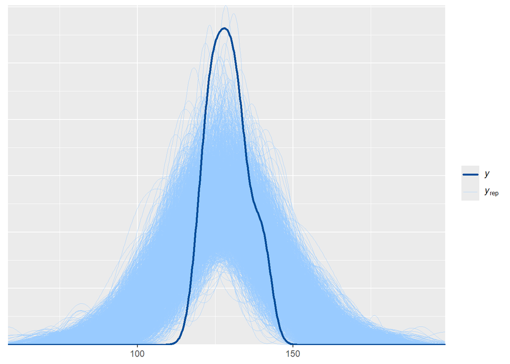

```r
## Code:
## Draws from the posterior predictive distribution
ppd_mod1 <- extract(fitted, "y_rep" )
ppd_mod2 <- extract(fitted2, "y_rep" )

color_scheme_set("brightblue")
ppc_dens_overlay(y, ppd_mod1$y_rep)
```

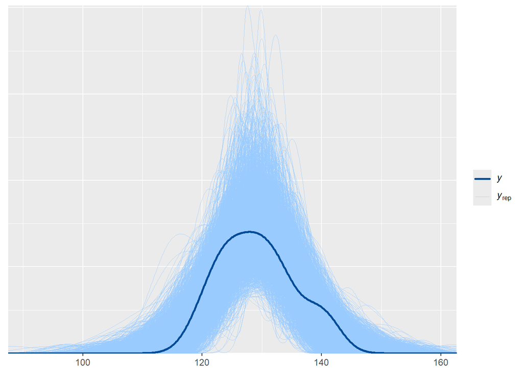

```r
ppc_dens_overlay(y, ppd_mod2$y_rep)
```

# Question 5

Write the same model, as in Question 3, with brms and recreate the plot for that model as in Question 4:

```r
## Code:

brm_mod <- brms::brm(y ~ 1,
          family = gaussian(),
          data = as.data.frame(stan_data),
          prior = prior(normal(100, 10), class = Intercept) +
            prior(gamma(10, 1), class = sigma),
          file = "model_hw6.rds")
```

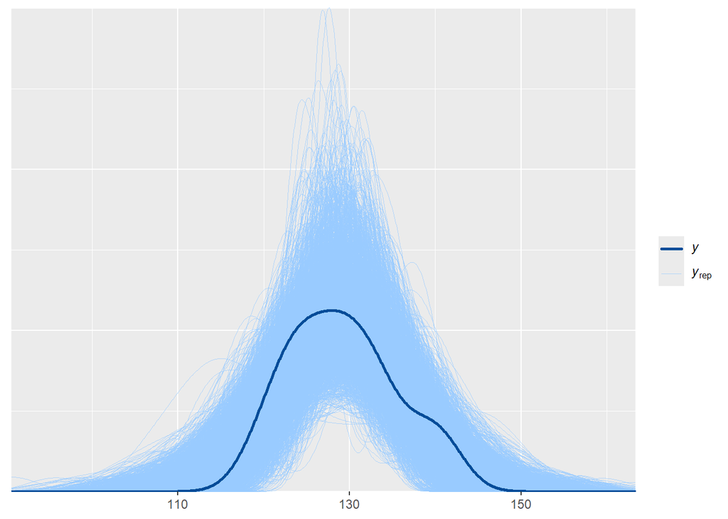

```r
brm_mod <- readRDS("model_hw6.rds")

pp <- brms::posterior_predict(brm_mod)

ppc_dens_overlay(y, pp)
```